# Exploracion

March 5, 2019

# 1 Carga de Datos

Los datos estan en los siguientes dos archivos.

```r
# Carguemos los archivos y luego escribamolos en un RData
#train_raw <- read_csv("data/mnist_train.csv", col_names = FALSE)
#test_raw <- read_csv("data/mnist_test.csv", col_names = FALSE)
#save(train_raw, test_raw, file = "data/mnist_data.RData")
# mnist_data.RData (20Mb)
# Sigamos cargando los datos desde mnist_data.RData
# que es mucho más rápido
load(file = "data/mnist_data.RData")
```

Exploremos la información

```r
str(train_raw,max.level = 0)
```

```
## Classes 'tbl_df', 'tbl' and 'data.frame':    60000 obs. of  785 variables:
##  - attr(*, "spec")=List of 2
##   ..- attr(*, "class")= chr "col_spec"
```

En el conjunto de train tenemos 60k de imágenes. Cada fila tiene 785 columnas donde la primera columna es el dígito en la imágen y las otras 784 son los 28x28 pixeles de cada imágen.

Cómo estan las proporciones de cada clase?

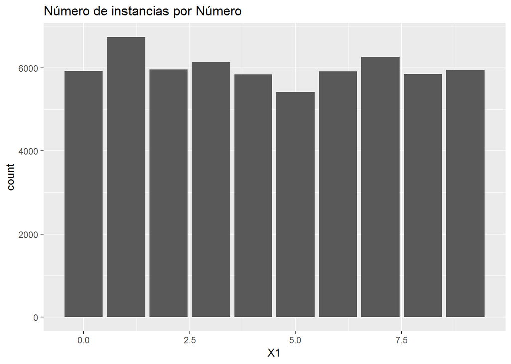

```r
train_raw %>%
  ggplot(aes(X1)) +
  geom_bar() +
  labs(title = "Número de instancias por Número")
```

Es un dataset bastante balanciado en el número de instancias para cada clase.

Tratemos de visualizar algunos de los datos. Para esto, hagamos una transformación de una parte de los datos.

```r
# Transformando los datos para visualización
pixels_gathered <- train_raw %>%
  head(10000) %>%
  rename(label = X1) %>%
  mutate(instance = row_number()) %>%
  gather(pixel, value, -label, -instance) %>%
  tidyr::extract(pixel, "pixel", "(\\d+)", convert = TRUE) %>%
  mutate(pixel = pixel - 2,
         x = pixel %% 28,
         y = 28 - pixel %/% 28)
pixels_gathered
```

```
## # A tibble: 7,840,000 x 6
##    label instance pixel value     x     y
##    <int>    <int> <dbl> <int> <dbl> <dbl>
##  1     5        1     0     0     0    28
##  2     0        2     0     0     0    28
##  3     4        3     0     0     0    28
##  4     1        4     0     0     0    28
##  5     9        5     0     0     0    28
##  6     2        6     0     0     0    28
##  7     1        7     0     0     0    28
##  8     3        8     0     0     0    28
##  9     1        9     0     0     0    28
## 10     4       10     0     0     0    28
## # ... with 7,839,990 more rows
```

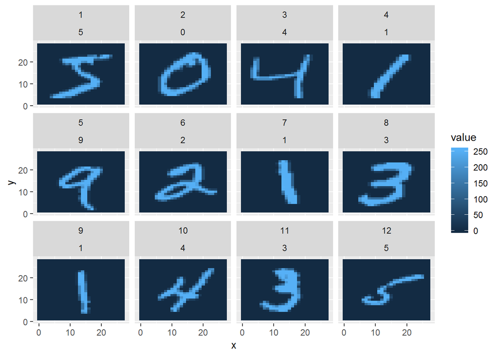

```r
# Aprendiendo a visualizar imagenes en ggplot
pixels_gathered %>%
  filter(instance <= 12) %>%
  ggplot(aes(x, y, fill = value)) +
  geom_tile() +
  facet_wrap(~ instance + label)
```

Estas son las primeras 12 instancias del dataset con su respectiva clase de dígito.

Ahora hagamos la conversion de (0-255) a la escala (0-1) y pongamos la primera columna como un factor llamdo label

```r
train <- train_raw %>%
  mutate_at(vars(X2:X785),funs(. / 255)) %>%
  rename(label = X1) %>%
  mutate(label = factor(label))
test <- test_raw %>%
  mutate_at(vars(X2:X785),funs(. / 255)) %>%
  rename(label = X1) %>%
  mutate(label = factor(label))
```

# 2 Modelos

## 2.1 Creación de Dataframe para Validación Cruzada

Hagamos un dataframe para probar los tiempos de procesamiento con 2 pliegues y 2 repeticiones sobre el 10% de los datos de entrenamiento.

```r
# Empecemos con una version que use 5 pliegues sobre el 10% de los datos
v <- 2 # Número de Pliegues
r <- 2 # Número de Repeteciones
frac <- 0.1
set.seed(71265)
cv_data <- vfold_cv(train %>%
                      sample_frac(frac) ,
                    v = v,
                    repeats = r) %>%
  mutate(analysis = map(splits,~analysis(.x)),
         assessment = map(splits,~assessment(.x)),
         y.assessment = map(assessment,~factor(.x$label)))
cv_data
```

```
## #  2-fold cross-validation repeated 2 times
## # A tibble: 4 x 6
##   splits       id      id2   analysis         assessment       y.assessment
## * <list>       <chr>   <chr> <list>           <list>           <list>
## 1 <split [3K/~ Repeat1 Fold1 <tibble [3,000 ~ <tibble [3,000 ~ <fct [3,000~
## 2 <split [3K/~ Repeat1 Fold2 <tibble [3,000 ~ <tibble [3,000 ~ <fct [3,000~
## 3 <split [3K/~ Repeat2 Fold1 <tibble [3,000 ~ <tibble [3,000 ~ <fct [3,000~
## 4 <split [3K/~ Repeat2 Fold2 <tibble [3,000 ~ <tibble [3,000 ~ <fct [3,000~
```

## 2.2 Modelo con SVM

### 2.2.1 Tiempo de Entrenamiento y Prueba

Evalumos cuando se demora el modelo SVM en entranmiento con un subconjunto de 3000 datos.

```r
# Ensayemos los tiempos de entrenamiento
d <- train %>% sample_n(3000)
start <- Sys.time()
mod <- kernlab::ksvm(label ~ . , data = d, C = 100)
end_trai_svm_3000 <- Sys.time() - start
end_trai_svm_3000
```

```
## Time difference of 22.79329 secs
```

Se demora 1.3 minutos entrenando un SVM con 6000 muestras. Se demora unos 23 segundos entrenando un modelo con 3000 muestras.

Ahora miremos el tiempo que demora el modelo para predecir el mismo número de instancias.

```r
start <- Sys.time()
pred <- kernlab::predict(mod,(d %>% select(-label)))
time_pred_svm_3000 <- Sys.time() - start
time_pred_svm_3000
```

```
## Time difference of 23.32753 secs
```

Se demora 53 segundos prediciendo 6000 muestras con el modelo entrenado anteriormente. Se demora unos 23 segunos entrenando con 3000 muestras.

### 2.2.2 Modelo sin Paralelizar

Ahora hagamos validacion cruzada para 3 valores del parametro C. En total estamos entrenando 12 modelos en el 10% de los datos.

```r
# Validemos para 3 valores de C.
start <- Sys.time()
modeloSVM <- cv_data %>%
  crossing(C = c(1,10,100)) %>%
  mutate(modeloSVM = map2(analysis,C,~kernlab::ksvm(label ~ . ,
                                                 data = .x,
                                                 C = .y)),
         y.pred = map2(modeloSVM,assessment, ~kernlab::predict(.x,.y)),
         validate_ce = map2_dbl(y.assessment,y.pred,~ce(.x,.y)))
SVM_time_serie <- Sys.time() - start
SVM_time_serie
```

```
## Time difference of 11.18723 mins
```

Se demoro 11 miuntos con el 10 porciento de los datos, con 2 pliegues, dos repeticiones y la evalucion de 3 parametros (para un total del 12 modelos). Un promedio de modelo por minuto.

```r
modeloSVM %>%
  group_by(C) %>%
  summarize(meanCe = mean(validate_ce))
```

```
## # A tibble: 3 x 2
##       C meanCe
##   <dbl>  <dbl>
## 1     1 0.0595
## 2    10 0.0516
## 3   100 0.0519
```

### 2.2.3 Rendimiento en Test

Escojamos el mejor parametro C del modelo en entrenamiento y miremos como le va al modelo en el conjunto de prueba.

```r
bestC <- modeloSVM %>%
  group_by(C) %>%
  summarize(meanCe = mean(validate_ce)) %>%
  ungroup() %>%
  filter( meanCe == min(meanCe) ) %>%
  .$C
bestC
```

```
## [1] 10
```

Entrenemos un modelo con el valor de C encontrado anteriormente y examinemos su rendimiento en los dato de prueba.

```r
d <- train %>% sample_n(3000)
mod <- kernlab::ksvm(label ~ . , data = d, C = 10)
pred <- kernlab::predict(mod,(test %>% select(-label)))
errorSVMTesting <- ce(test$label,pred)
errorSVMTesting
```

```
## [1] 0.0529
```

### 2.2.4 Modelo Paralelizado

Ensayemos hacer el procesamiento en paralelo. Esta forma de procesamiento en paralelo está explicada en el siguiente enlace: https://www.r-bloggers.com/speed-up-your-code-parallel-processing-with-multidplyr/

Detectemos el número de cores

```r
library(parallel)
cl <- detectCores()
cl
```

```
## [1] 4
```

Creemos un cluster con multidplyr

```r
library(multidplyr)
cluster <- create_cluster(cores = cl)
```

```
## Initialising 4 core cluster.
```

```r
cluster
```

```
## socket cluster with 4 nodes on host 'localhost'
```

Ahora creemos un dataframe que tenga los valores de los parametros a probar

```r
modeloSVM <- cv_data %>%
  crossing(C = c(1,10,100))
```

Asignemos los datos de cada pliegue a un core

```r
group <- rep(1:cl, length.out = nrow(modeloSVM))
modeloSVM <- bind_cols(tibble(group), modeloSVM)
```

Ahora creemos las particiones de los datos para cada cluster

```r
by_group <- modeloSVM %>%
    partition(group, cluster = cluster)
```

Ahora, alistemos las funciones, variables y librerias que necesita cada uno de los componentes del cluster

```r
by_group %>%
    # Assign libraries
    cluster_library("tidyverse") %>%
    cluster_library("kernlab") %>%
    cluster_library("Metrics")
```

Verifiquemos que quedaron bien asigandas las librearias

```r
cluster_eval(by_group, search())[[1]]
```

```
##  [1] ".GlobalEnv"        "package:Metrics"   "package:kernlab"
##  [4] "package:forcats"   "package:stringr"   "package:dplyr"
##  [7] "package:purrr"     "package:readr"     "package:tidyr"
## [10] "package:tibble"    "package:ggplot2"   "package:tidyverse"
## [13] "package:stats"     "package:graphics"  "package:grDevices"
## [16] "package:utils"     "package:datasets"  "package:methods"
## [19] "Autoloads"         "package:base"
```

Ahora, corramos el código en paralelo

```r
start <- Sys.time() # Start clock
modeloSVM_parallel <- by_group %>% # Use by_group party_df
    mutate(modeloSVM = map2(analysis,C,~kernlab::ksvm(label ~ . ,
                                                 data = .x,
                                                 C = .y)),
           y.pred = map2(modeloSVM,assessment, ~kernlab::predict(.x,.y)),
           validate_ce = map2_dbl(y.assessment,y.pred,~ce(.x,.y))) %>%
    collect() %>% # Special collect() function to recombine partitions
    as_tibble()   # Convert to tibble
time_elapsed_parallel <- Sys.time() - start # End clock
time_elapsed_parallel
```

```
## Time difference of 6.662209 mins
```

Veamos el resultado

```r
if (r==1){
  results <- modeloSVM_parallel %>%
    group_by(C) %>%
    summarise(meanCE = mean(validate_ce))
} else {
  results <- modeloSVM_parallel %>%
    group_by(C,id) %>%
    summarise(meanCE = mean(validate_ce)) %>%
    group_by(C) %>%
    summarise(meanCE = mean(meanCE),
              var = var(meanCE))
}
results
```

```
## # A tibble: 3 x 3
##       C meanCE   var
##   <dbl>  <dbl> <dbl>
## 1     1 0.0594    NA
## 2    10 0.0518    NA
## 3   100 0.052     NA
```

Mejor C

```r
bestC <- results %>%
  filter( meanCE == min(meanCE) ) %>%
  .$C
bestC
```

```
## [1] 10
```

### 2.2.5 Modelo Entrenado en la Nube

Dado que correr el SVM con más pliegues es muy costo en memoria y computacionalmente, vamos a probar con el procesamiento en la nube usando 5 pliegues, dos repeticiones y 6 valores del parámetro C. Vamos a usar una instancia m4.16xlarge de Amazon Elastic Computing (EC) para correr estos 60 modelos (5 pliegues x 2 repeticiones x 6 parámetros). Las razones para correr el entramiento de este modelo en la nube fueron:

- El entramiento con el SVM estaba generando unos requerimientos en RAM muy grandes que no lo dejaban correr en la maquina local.
- El reto de entrenar un modelo en la nube usando una instancia con mucho mayor poder de memoria y procesamiento.

El código que se puso a correr en Amazon EC se puede encontrar en el archivo ModeloSVM.R

#### 2.2.5.1 Entrenamiento en validación cruzada

A continuación estan los datos del modelo entrenado en la nube.

Miremos los valores de tasa de clasificación incorrecta para diferentes valores de del parámetro C.

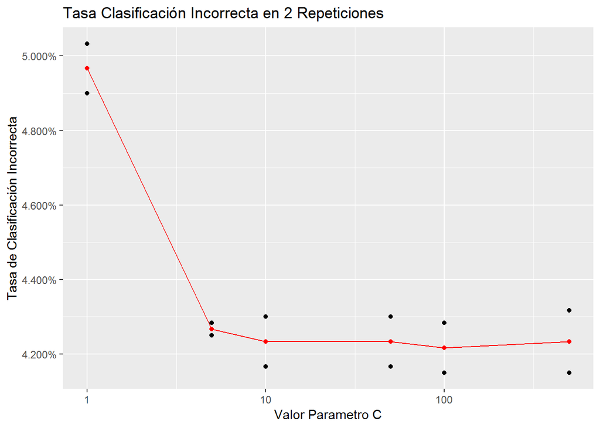

```r
load("SVMTrain_v5_r2_frac10percentRESULTS.RData")
trainSVMResults %>%
  group_by(C,id) %>%
  summarise(meanCE = mean(validate_ce)) %>%
  ggplot(aes(C,meanCE)) +
  geom_point() +
  stat_summary(fun.y = mean, geom = "point", col = "red") +
  stat_summary(fun.y = mean, geom = "line", col = "red", aes(group = 1)) +
  scale_x_log10() +
  labs(title = "Tasa Clasificación Incorrecta en 2 Repeticiones",
       x = "Valor Parametro C",
       y = "Tasa de Clasificación Incorrecta") +
  scale_y_continuous(labels = percent_format())
```

En el gráfico, la linea roja es la tasa media de clasificación incorrecta entre las repeticiones. Se puede ver que las tasas de error para parámetros desde 10 hasta 500 son bastantes parecidas, con 100 como el mejor valor para el parámetro C en estos datos.

Miremos también cuanto tiempo duró el procesamiento de estos 60 modelos.

```r
time_elapsed_parallel
```

```
##    user  system elapsed
##  18.684  11.980 858.802
```

Los 60 modelos se entrenaron en la nube en 15 minutos. Esto equivale a aproximadamente un cuarto del tiempo que hubiera tomado el procesamiento en serie en este computador

#### 2.2.5.2 Validación

Ahora miremos el tiempo de entrenamiento y el la tasa de clasificación incorrecta que obtuvo el modelo entrenado en la nube con todos los datos de entrenamiento y el parametro C con el valor de 100.

```r
load("SVMTest_C100_allData.RData")
# Miremos primero cuanto se demoro en entrenar
test_time
```

```
##      user    system   elapsed
##  1921.724 26389.924   808.886
```

Ahora miremos el error en el conjunto de prueba

```r
errorSVMTesting
```

```
## [1] 0.0176
```

Este modelo obtuvo un error del 1.76% de tasa de clasificación incorrecta.

## 2.3 Modelo con GLM Multinomial

Hagamos un modelo GLM Multinomial con penalizacion elástica usando glment.

### 2.3.1 Tiempos de Entrenamiento y Prueba

Probemos cuanto se demora con 3000 los datos y usando Lasso (alpha=1)

```r
n <- 3000
d <- train %>% sample_n(n)
start_glm <- Sys.time()
modGLM <- glmnetUtils::glmnet(label ~ . , data = d, family = "multinomial", alpha = 1)
end_glm <- Sys.time()
glm_train_time <-  end_glm - start_glm
glm_train_time
```

```
## Time difference of 2.070201 mins
```

Ahora ensayemos los tiempos de predicción.

```r
start_glm <- Sys.time()
y.pred <- predict(modGLM,test, type = "class", s=modGLM$lambda[1])
errorGLMTest <- ce(test$label,y.pred)
glm_test_time <-  Sys.time() - start_glm
glm_test_time
errorGLMTest
```

```
## Time difference of 4.978948 secs
```

```
## [1] 0.8865
```

Este modelo es bastante rápido al predecir ya que pronostica 10k de datos en 5 segundos pero tiene un tasa de clasificación incorrecta bastante mala con el 89%.

### 2.3.2 Entrenamiento con Validación Cruzada

Carguemos los datos que se usaron en el servidor para que sirvan de base para el resto de modelos.

```r
load("cv_data.RData")
cv_data
```

```
## # A tibble: 10 x 5
##    id      id2   analysis               assessment             y.assessment
##    <chr>   <chr> <list>                 <list>                 <list>
##  1 Repeat1 Fold4 <tibble [4,800 x 785]> <tibble [1,200 x 785]> <fct [1,200~
##  2 Repeat2 Fold5 <tibble [4,800 x 785]> <tibble [1,200 x 785]> <fct [1,200~
##  3 Repeat2 Fold1 <tibble [4,800 x 785]> <tibble [1,200 x 785]> <fct [1,200~
##  4 Repeat1 Fold3 <tibble [4,800 x 785]> <tibble [1,200 x 785]> <fct [1,200~
##  5 Repeat1 Fold1 <tibble [4,800 x 785]> <tibble [1,200 x 785]> <fct [1,200~
##  6 Repeat1 Fold5 <tibble [4,800 x 785]> <tibble [1,200 x 785]> <fct [1,200~
##  7 Repeat1 Fold2 <tibble [4,800 x 785]> <tibble [1,200 x 785]> <fct [1,200~
##  8 Repeat2 Fold3 <tibble [4,800 x 785]> <tibble [1,200 x 785]> <fct [1,200~
##  9 Repeat2 Fold2 <tibble [4,800 x 785]> <tibble [1,200 x 785]> <fct [1,200~
## 10 Repeat2 Fold4 <tibble [4,800 x 785]> <tibble [1,200 x 785]> <fct [1,200~
```

Estos datos corresponden a 5 pliegues y 2 repeticiones usando el 10% de los datos.

Ahora entrenemos un GLM en estos datos para 3 valores de alpha (0,0.5,1). Esto nos da unos modelos Ridge, Elasticnet Ridge-Lasso, y Lasso.

```r
library(parallel)
cl <- detectCores()
library(multidplyr)
cluster <- create_cluster(cores = cl)

# Agregemos los diferentes modelos a calcular
modeloGLM <- cv_data %>%
  crossing(alpha = c(0,0.5,1))

group <- rep(1:cl, length.out = nrow(modeloGLM))
modeloGLM <- bind_cols(tibble(group), modeloGLM)

by_group <- modeloGLM %>%
    partition(group, cluster = cluster)

by_group %>%
    cluster_library("tidyverse") %>%
    cluster_library("glmnet") %>%
    cluster_library("glmnetUtils") %>%
    cluster_library("Metrics")

start <- Sys.time() # Start clock
modeloGLM_parallel <- by_group %>% # Use by_group party_df
    mutate(modeloGLM = map2(analysis,alpha,~glmnetUtils::glmnet(label ~ . ,
                                                 data = .x,
                                                 family = "multinomial",
                                                 alpha = .y)),
           lambda = map_dbl(modeloGLM,~(.x$lambda[1])),
           y.pred = map2(modeloGLM,assessment, ~predict(.x,.y, type = "class", s = .x$lambda[1])),
           validate_ce = map2_dbl(y.assessment,y.pred,~ce(.x,.y))) %>%
    collect() %>%
    as_tibble()
time_GLM_parallel <- Sys.time() - start
time_GLM_parallel
```

```
## Time difference of 1.095639 hours
```

Le tomó una hora y 6 minutos calcular estos 30 modelos con 4 procesadores.

Veamos el resultado

```r
results <- modeloGLM_parallel %>%
  group_by(alpha,id) %>%
  summarise(meanCE = mean(validate_ce),
            lambda = mean(lambda)) %>%
  group_by(alpha) %>%
  summarise(meanCE = mean(meanCE),
            lambda = mean(lambda))
results
```

```
## # A tibble: 3 x 3
##   alpha meanCE  lambda
##   <dbl>  <dbl>   <dbl>
## 1   0    0.885 179.
## 2   0.5  0.885   0.358
## 3   1    0.885   0.179
```

Parece que hay una gran cantidad de datos, el parámetro alpha no hiciera mucha diferencia. Escojamos un alpha de 0.5 en el resto de procesamiento.

### 2.3.3 Entrenamiento del Modelo Final

Ahora entrenemos un modelo GLM con estos parametros.

```r
start_glm <- Sys.time()
modGLM_All <- glmnetUtils::glmnet(label ~ . , data = train, family = "multinomial", alpha = 0.5)
glm_test_time <-  Sys.time() - start_glm
glm_test_time
```

```
## Time difference of 1.042845 hours
```

El entrenamiento del modelo GLM con los 60k datos duro un poco más de una hora.

### 2.3.4 Rendimiento en Datos de Prueba

```r
y.pred <- predict(modGLM_All,test, type = "class", s=modGLM_All$lambda[1])
errorGLMTest_All <- ce(test$label,y.pred)
errorGLMTest_All
```

```
## [1] 0.8865
```

## 2.4 Modelo con CART

### 2.4.1 Modo Gini

Ahora probemos con el arboles de clasificación. Empecemos usando la medida “Gini” para escoger la variable de división.

```r
library(rpart)
start <- Sys.time()
modCARTGini <- rpart::rpart(label ~ . , data = train, method = "class", parms = list(split = "gini"))
cart_train_gini_time <-  Sys.time() - start
cart_train_gini_time
```

```
## Time difference of 3.701272 mins
```

Un poco mas de 3 minutos y medio para entrar en todo el conjunto de entrenamiento, lo que lo hace un método bastante rápido.

Ahora hagamos predición con este modelo sobre el conjunto de prueba.

```r
start <- Sys.time()
y.pred <- predict(modCARTGini,test, type = "class")
errorCARTGini <- ce(test$label,y.pred)
cart_pred_time_gini <-  Sys.time() - start
cart_pred_time_gini
errorCARTGini
```

```
## Time difference of 1.300345 secs
```

```
## [1] 0.3804
```

Se demoró 2 segundos prediciendo 10k datos de prueba y obtuvo una tasa de clasificación incorrecta de solo el 38%. Esta tasa de clasificación incorrecto también es bastante alta (mala).

### 2.4.2 Modo Information

Ahora examinemos el modelo usando la medida “information”.

```r
library(rpart)
start <- Sys.time()
modCARTInf <- rpart::rpart(label ~ . , data = train, method = "class", parms = list(split = "information"))
cart_train_inf_time <-  Sys.time() - start
cart_train_inf_time
```

```
## Time difference of 3.454528 mins
```

Un poco mas de 3 minutos y medio para entrar en todo el conjunto de entrenamiento.

Ahora hagamos predición con este modelo sobre el conjunto de prueba.

```r
start <- Sys.time()
y.pred <- predict(modCARTInf,test, type = "class")
errorCARTGInf <- ce(test$label,y.pred)
cart_pred_time_inf <-  Sys.time() - start
cart_pred_time_inf
errorCARTGInf
```

```
## Time difference of 0.7359369 secs
```

```
## [1] 0.3407
```

Se demoró solo segundo prediciendo pero con un tasa de calsificación incorrecta del 34%. Una tasa levemente mejor que usando “gini”.

## 2.5 Modelo con Random Forest

Probemos la implementación de RandomForest del paquete “Ranger” que parece tener una implementación más veloz que la version original.

### 2.5.1 Tiempo de Entrenamiento y Prueba

```r
library(ranger)
d <- train %>% sample_n(3000)
start <- Sys.time()
modRF3000 <- ranger::ranger(label ~ . , data = d, num.trees = 500)
rf_train_3000_time <-  Sys.time() - start
rf_train_3000_time
```

```
## Time difference of 6.68453 secs
```

Ahora hagamos predición con este modelo sobre el conjunto de prueba.

```r
start <- Sys.time()
y.pred <- predict(modRF3000,test, type = "response")
errorRF3000 <- ce(test$label,y.pred$predictions)
rf_pred_time_3000 <-  Sys.time() - start
rf_pred_time_3000
errorRF3000
```

```
## Time difference of 1.809193 secs
```

```
## [1] 1
```

### 2.5.2 Entrenamiento con Validación Cruzada

```r
library(parallel)
cl <- detectCores()
library(multidplyr)
cluster <- create_cluster(cores = cl)

# Agregemos los diferentes modelos a calcular
modeloRF <- cv_data %>%
  crossing(num.trees = c(100,250,500,1000))

group <- rep(1:cl, length.out = nrow(modeloRF))
modeloRF <- bind_cols(tibble(group), modeloRF)

by_group <- modeloRF %>%
    partition(group, cluster = cluster)

by_group %>%
    cluster_library("tidyverse") %>%
    cluster_library("ranger") %>%
    cluster_library("Metrics")

start <- Sys.time()
modeloRF_parallel <- by_group %>%
    mutate(modeloRF = map2(analysis,num.trees,~ranger::ranger(label ~ . ,
                                                 data = .x,
                                                 num.trees = .y)),
           y.pred = map2(modeloRF,assessment, ~predict(.x,.y, type = "response")),
           validate_ce = map2_dbl(y.assessment,y.pred,~ce(.x,(.y)$predictions))) %>%
    collect() %>%
    as_tibble()
time_RF_parallel <- Sys.time() - start
time_RF_parallel
```

```
## Time difference of 10.72332 mins
```

Veamos el resultado

```r
results <- modeloRF_parallel %>%
  group_by(num.trees,id) %>%
  summarise(meanCE = mean(validate_ce)) %>%
  group_by(num.trees) %>%
  summarise(meanCE = mean(meanCE))
results
```

```
## # A tibble: 4 x 2
##   num.trees meanCE
##       <dbl>  <dbl>
## 1       100 0.0636
## 2       250 0.0598
## 3       500 0.0585
## 4      1000 0.059
```

Veamos los valores gráficamente

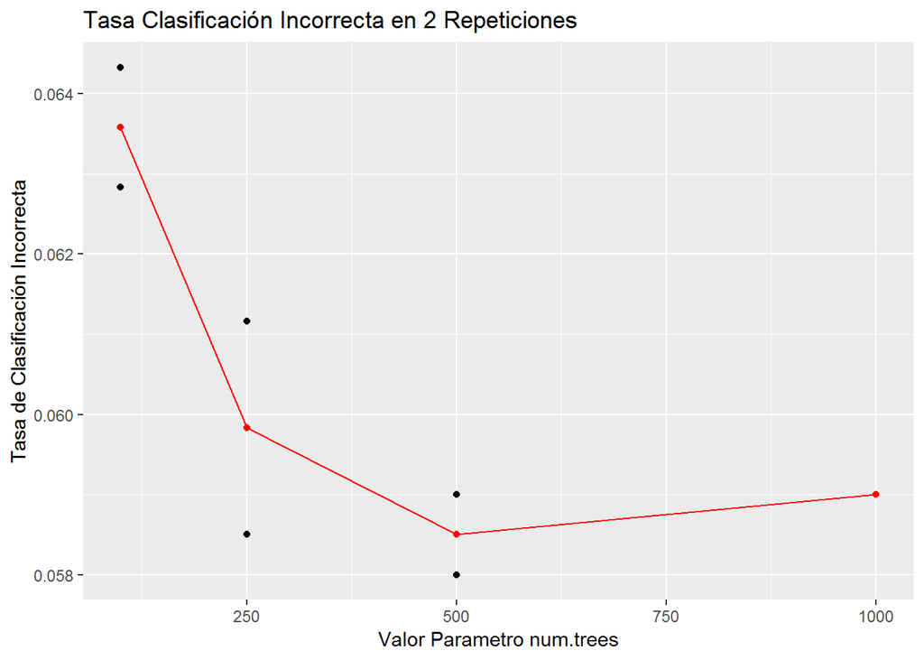

```r
modeloRF_parallel %>%
  group_by(num.trees,id) %>%
  summarise(meanCE = mean(validate_ce)) %>%
  ggplot(aes(num.trees,meanCE)) +
  geom_point() +
  stat_summary(fun.y = mean, geom = "point", col = "red") +
  stat_summary(fun.y = mean, geom = "line", col = "red", aes(group = 1)) +
  labs(title = "Tasa Clasificación Incorrecta en 2 Repeticiones",
       x = "Valor Parametro num.trees",
       y = "Tasa de Clasificación Incorrecta")
```

Parecieran faltar los puntos de las repeticiones cuando num.trees es igual a 1000 pero la realidad es que ambas repeticiones obtuvieron la misma tasa de clasificación incorrecta y eso hace que los 3 puntos queden solapados.

### 2.5.3 Entrenamiento del Modelo Final

Ahora entrenemos un modelo de RandomForest con 500 arboles.

```r
start <- Sys.time()
modRF_All <- ranger::ranger(label ~ . , data = train, num.trees = 500)
rf_test_time <-  Sys.time() - start
rf_test_time
```

```
## Time difference of 4.854916 mins
```

Solo se demoró 5 minutos entrenando 500 arboles en los 60k de datos de entrenamiento. Impresionante.

### 2.5.4 Rendimiento en Datos de Prueba

```r
start <- Sys.time()
y.pred <- predict(modRF_All,test, type = "response")
errorRFTest_All <- ce(test$label,y.pred$predictions)
rf_pred_test_time <-  Sys.time() - start
errorRFTest_All
rf_pred_test_time
```

```
## [1] 0.0282
```

```
## Time difference of 8.969326 secs
```

El modelo obtuvo una tasa de clasificación incorrecta del 2.82% que es levemente peor a la tasa del SVM que fue del 1.7%. Sin embargo, los tiempo de entrenamiento mucho más cortos.

La predicción de los 10k datos del conjunto de pruebala hizo en solo 9 segundos.

## 2.6 Model con Redes Neuronales

Modelo de redes neuronales con el modelo mxnet. Carguemos la libreria

```r
library(mxnet)
```

Arquitectura del modelo

```r
data <- mx.symbol.Variable("data")
fc1 <- mx.symbol.FullyConnected(data, name="fc1", num_hidden=128)
act1 <- mx.symbol.Activation(fc1, name="relu1", act_type="relu")
fc2 <- mx.symbol.FullyConnected(act1, name="fc2", num_hidden=64)
act2 <- mx.symbol.Activation(fc2, name="relu2", act_type="relu")
fc3 <- mx.symbol.FullyConnected(act2, name="fc3", num_hidden=10)
softmax <- mx.symbol.SoftmaxOutput(fc3, name="sm")
```

Procesamiento en CPU

```r
devices <- mx.cpu() # Esto es para utilizar el procesador en lugar de la tarjeta gráfica.
```

### 2.6.1 Tiempos de Entrenamiento y Prueba

Entrenamiento

```r
load(file = "data/mnist_data_normalized.RData")
```

```r
start <- Sys.time()
mx.set.seed(0)
modeloNN <- mx.model.FeedForward.create(softmax, X=data.matrix(train[,-1]), y=(as.integer(train$label)-1),
                                     ctx=devices, num.round=10, array.batch.size=100,
                                     learning.rate=0.07 , momentum=0.9,  eval.metric=mx.metric.accuracy,
                                     initializer=mx.init.uniform(0.07),
                                     epoch.end.callback=mx.callback.log.train.metric(100))
time_train_NN <- Sys.time() - start
time_train_NN
```

```
## Time difference of 47.49837 secs
```

Un 50 segundos para entrenar el modelo en los 60k datos de entrenamiento. Esto quiere decir que un modelo con 3000 datos se entrena en unos 3 segundos bajo la configuración actual

Prediccion

```r
start <- Sys.time()
test_y_pred_matrix<- predict(modeloNN,X=test_x)
test_y_pred <- max.col(t(test_y_pred_matrix)) - 1
errorNN <- ce(test_y,test_y_pred)
time_pred_NN <- Sys.time() - start
time_pred_NN
errorNN
```

```
## Time difference of 0.4117899 secs
```

```
## [1] 0.0251
```

Predice los 10k datos del conjunto prueba en menos de un segundo y con una tasa de clasificación incorrecta del 2.51%

### 2.6.2 Entrenamiento con Validación Cruzada

Creemos una validación cruzada con 10 pliegues sobre 10 porciento de los datos.

```r
set.seed(71265)
cv_data_nn <- train %>%
  sample_frac(0.1) %>%
  vfold_cv(v=10)  %>%
  mutate(analysis = map(splits,~analysis(.x)),
         assessment = map(splits,~assessment(.x)),
         y.assessment = map(assessment,~factor(.x$label)),
         data = map(analysis,~data.matrix(.x)))
```

Dado que la libreria MX ya hace uso de las capacidades multi-core del computador, no es necesario hacer un procesamiento en paralelo para la validación cruzada.

```r
start <- Sys.time()
modeloNN_parallel <- cv_data_nn  %>%
    mutate(modeloNN = map(data,~mx.model.FeedForward.create(softmax,
                                                            X=.x[,-1],
                                                            y=(.x[,1]-1),
                                                            ctx=devices,
                                                            num.round=10,
                                                            array.batch.size=100,
                                                            learning.rate=0.07,
                                                            momentum=0.9,
                                                            eval.metric=mx.metric.accuracy,
                                                            initializer=mx.init.uniform(0.07))),
           y.pred_matrix = map2(modeloNN,assessment, ~predict(.x, X = data.matrix(.y[,-1]))),
           y.pred = map(y.pred_matrix,~(max.col(t(.x)) - 1)),
           validate_ce = map2_dbl(y.assessment,y.pred,~ce(.x,.y))) %>%
  select(id,validate_ce)
time_NN_parallel <- Sys.time() - start
time_NN_parallel
```

```
## Time difference of 45.72326 secs
```

Se demora 45 segundos para entrenar estos 10 modelos sobre el 10% de los datos de entrenamiento. No es mucho tiempo, lo que nos permitirá tratar de optimizarla un poco más.

Calculemos la tasa base antes de optimizar la red neuronal

```r
mean(modeloNN_parallel$validate_ce)
```

```
## [1] 0.0615
```

La tasa base es del 6.15%

#### 2.6.2.1 Optimizando la tasa de aprendizaje

Recomiendan optimizar primero la tasa de aprendizaje mientras dejamos el resto igual.

```r
set.seed(0)
learning.rates <- c(0.0001,0.001,0.01,0.1,1)
start <- Sys.time()
modeloNN_LR <- cv_data_nn  %>%
  crossing(learning.rate = learning.rates) %>%
    mutate(modeloNN = map2(data,learning.rate,~mx.model.FeedForward.create(softmax,
                                                            X=.x[,-1],
                                                            y=(.x[,1]-1),
                                                            ctx=devices,
                                                            num.round=10,
                                                            array.batch.size=100,
                                                            learning.rate=.y,
                                                            momentum=0.9,
                                                            eval.metric=mx.metric.accuracy,
                                                            initializer=mx.init.uniform(0.07))),
           y.pred_matrix = map2(modeloNN,assessment, ~predict(.x, X = data.matrix(.y[,-1]))),
           y.pred = map(y.pred_matrix,~(max.col(t(.x)) - 1)),
           validate_ce = map2_dbl(y.assessment,y.pred,~ce(.x,.y))) %>%
  select(id,validate_ce,learning.rate)
time_NN_LR <- Sys.time() - start
time_NN_LR
```

```
## Time difference of 3.946907 mins
```

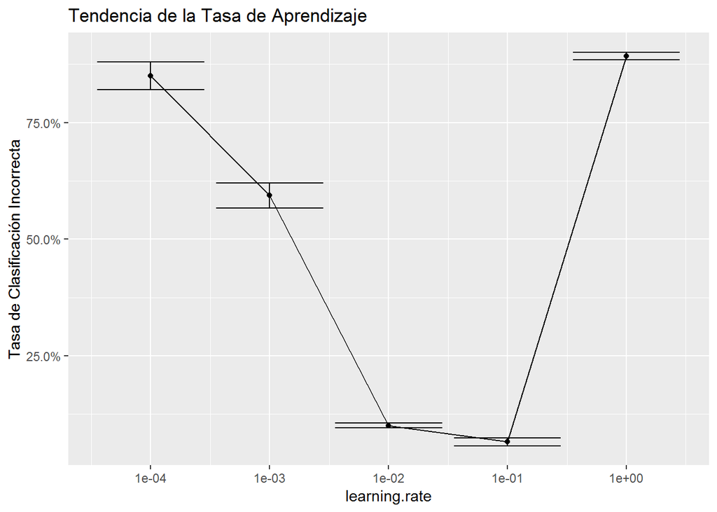

```r
modeloNN_LR %>%
  ggplot(aes(learning.rate,validate_ce)) +
  stat_summary(fun.y = mean, geom = "point") +
  stat_summary(fun.y = mean, geom = "line") +
  stat_summary(fun.data = mean_cl_normal, geom = "errorbar") +
  scale_x_log10() +
  scale_y_continuous(labels = percent_format()) +
  labs(title = "Tendencia de la Tasa de Aprendizaje",
       y = "Tasa de Clasificación Incorrecta")
```

#### 2.6.2.2 Optimizando el Batch Size

Ahora continuemos con el Batch Size

```r
set.seed(0)
batch.sizes <- c(10,50,100,500,1000)
start <- Sys.time()
modeloNN_BS <- cv_data_nn  %>%
  crossing(batch.size = batch.sizes) %>%
    mutate(modeloNN = map2(data,batch.size,~mx.model.FeedForward.create(softmax,
                                                            X=.x[,-1],
                                                            y=(.x[,1]-1),
                                                            ctx=devices,
                                                            num.round=10,
                                                            array.batch.size=.y,
                                                            learning.rate=0.1,
                                                            momentum=0.9,
                                                            eval.metric=mx.metric.accuracy,
                                                            initializer=mx.init.uniform(0.07))),
           y.pred_matrix = map2(modeloNN,assessment, ~predict(.x, X = data.matrix(.y[,-1]))),
           y.pred = map(y.pred_matrix,~(max.col(t(.x)) - 1)),
           validate_ce = map2_dbl(y.assessment,y.pred,~ce(.x,.y))) %>%
  select(id,validate_ce,batch.size)
time_NN_BS <- Sys.time() - start
time_NN_BS
```

```
## Time difference of 10.95224 mins
```

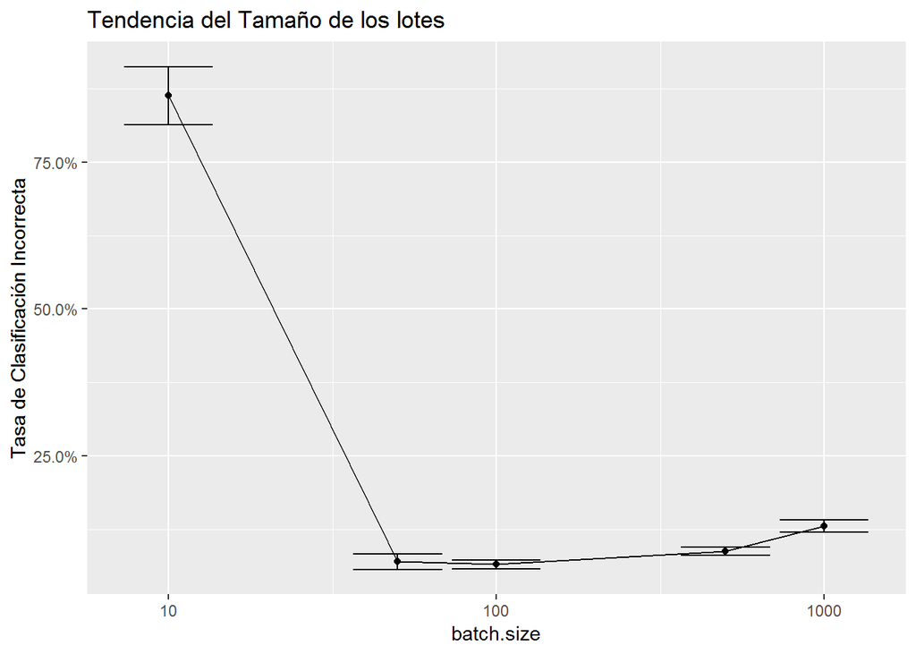

```r
modeloNN_BS %>%
  ggplot(aes(batch.size,validate_ce)) +
  stat_summary(fun.y = mean, geom = "point") +
  stat_summary(fun.y = mean, geom = "line") +
  stat_summary(fun.data = mean_cl_normal, geom = "errorbar") +
  scale_x_log10() +
  scale_y_continuous(labels = percent_format()) +
  labs(title = "Tendencia del Tamaño de los lotes",
       y = "Tasa de Clasificación Incorrecta")
```

100 sigue siendo el mejor valor para el tamaño del lote.

#### 2.6.2.3 Optimizando el Numero Epochs

Ahora continuemos con el número de iteraciones

```r
set.seed(0)
epochs <- c(5,10,20,50,100)
start <- Sys.time()
modeloNN_EP <- cv_data_nn  %>%
  crossing(epoch = epochs) %>%
    mutate(modeloNN = map2(data,epoch,~mx.model.FeedForward.create(softmax,
                                                            X=.x[,-1],
                                                            y=(.x[,1]-1),
                                                            ctx=devices,
                                                            num.round=.y,
                                                            array.batch.size=100,
                                                            learning.rate=0.1,
                                                            momentum=0.9,
                                                            eval.metric=mx.metric.accuracy,
                                                            initializer=mx.init.uniform(0.07))),
           y.pred_matrix = map2(modeloNN,assessment, ~predict(.x, X = data.matrix(.y[,-1]))),
           y.pred = map(y.pred_matrix,~(max.col(t(.x)) - 1)),
           validate_ce = map2_dbl(y.assessment,y.pred,~ce(.x,.y))) %>%
  select(id,validate_ce,epoch)
time_NN_EP <- Sys.time() - start
time_NN_EP
```

[output not shown]

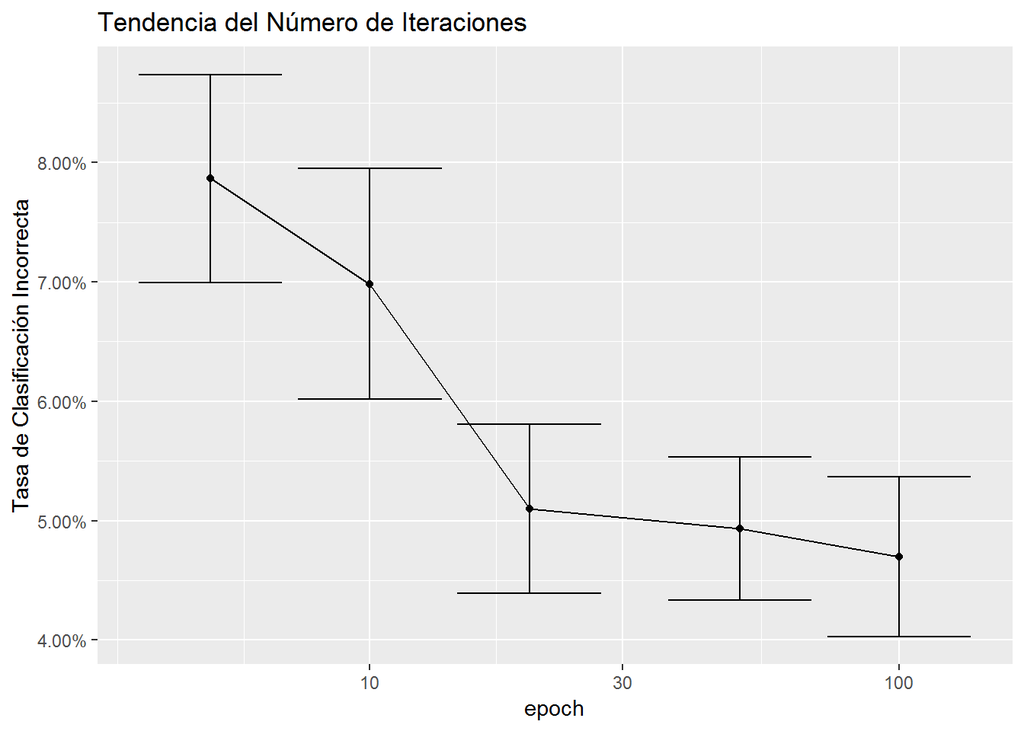

```r
modeloNN_EP %>%
  ggplot(aes(epoch,validate_ce)) +
  stat_summary(fun.y = mean, geom = "point") +
  stat_summary(fun.y = mean, geom = "line") +
  stat_summary(fun.data = mean_cl_normal, geom = "errorbar") +
  scale_x_log10() +
  scale_y_continuous(labels = percent_format()) +
  labs(title = "Tendencia del Número de Iteraciones",
       y = "Tasa de Clasificación Incorrecta")
```

Y 100 epochs hace que mejore aun más

### 2.6.3 Entrenamiento del Modelo Final

```r
load(file = "data/mnist_data_normalized.RData")
```

```r
start <- Sys.time()
mx.set.seed(0)
modeloNNF <- mx.model.FeedForward.create(softmax, X=data.matrix(train[,-1]), y=(as.integer(train$label)-1),
                                     ctx=devices, num.round=100, array.batch.size=100,
                                     learning.rate=0.1  , momentum=0.9,  eval.metric=mx.metric.accuracy,
                                     initializer=mx.init.uniform(0.07),
                                     epoch.end.callback=mx.callback.log.train.metric(100))
time_train_NN_Final <- Sys.time() - start
time_train_NN_Final
```

```
## Time difference of 8.508559 mins
```

### 2.6.4 Rendimiento en Datos de Prueba

```r
start <- Sys.time()
test_y_pred_matrix<- predict(modeloNNF,X=data.matrix(test[,-1]))
test_y_pred <- max.col(t(test_y_pred_matrix)) - 1
errorNNF <- ce(test$label,test_y_pred)
time_pred_NNF <- Sys.time() - start
time_pred_NNF
errorNNF
```

```
## Time difference of 0.7278271 secs
```

```
## [1] 0.0242
```

No tuvimos una mejora sustantiva.